# Funciones de varias variables

```python
!pip install sympy
```

```python
from sympy import *
from sympy.plotting import *
init_printing()
```

```python
x=symbols("x")
y=symbols("y")
z=symbols("z")
w=symbols("w")
```

Las funciones de una variable nos han permitido modelar muchas situaciones, al introducir más variables ampliaremos un poco el espectro de las aplicaciones de las matemáticas en la administración, para ello estudiaremos las funciones, sus dominios, las derivadas de funciones de varias variables, como también sus aplicaciones.

# Funciones de dos variables

Las funciones no siempre deben depender de una sola variable, en muchos casos las funciones dependen de más de una variable, por lo que se hace indispensable trabajar con funciones de éste tipo. Para tener un entendimiento de éste tipo de funciones trabajaremos con las más fáciles de comprender y trabajar que son las funciones de dos variables.

## Dominio

Al igual que en las funciones de una variable, el dominio es el conjunto de valores (en este caso parejas $(x,y)$) por los cuales se pueden remplazar las variables.

Por ejemplo, el dominio de la función $$f(x)=\sqrt{x}$$ son todos los valores no negativos de $x$, es decir $x\geq0$ o si se representa en un intervalo $[0,\infty).$

Mientras que si $$f(x,y)=\sqrt{x-y}$$ si dominio serán **todas** las posibles combinaciones que hagan que la resta $x-y$ sea no negativam en otras palabras $x\geq y$. Dicha desigualdad ya no se puede representar en un intervalo, se debe representar en un plano cartesiano

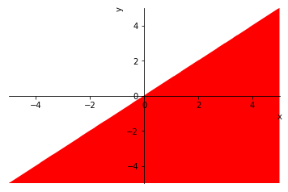

```
<sympy.plotting.plot.Plot at 0x7f41c58c64a8>
```

```python
plot_implicit(x-y>=0, line_color = 'r')
```

### Ejemplo:

Grafique el dominio de la función $$g(x,y)=\sqrt{x^2+y^2-1}$$

#### Solución:

Para poder calcular la raíz cuadrada el argumento debe ser un número no negativo, es decir, se necesita que $$x^2+y^2-1\geq0$$ por lo tanto la gráfica de ésta desigualdad es:

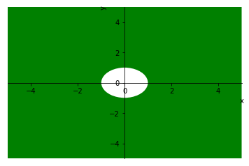

```
<sympy.plotting.plot.Plot at 0x7f41c58c6048>
```

```python
plot_implicit(x**2+y**2>=1, line_color = 'g')
```

### Ejercicios

Halle el dominio de las siguientes funciones:

1. $f(x,y)=\frac{x}{x+y}$.
2. $f(x,y)=\frac{1}{ln(2x+3y)}$
3. $f(x,y)=\frac{2x}{\sqrt{2x-y}}$

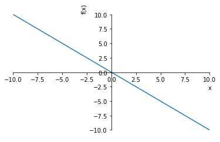

```
<sympy.plotting.plot.Plot at 0x7f41c4873ac8>
```

```python
plot(-x, show=True)
```

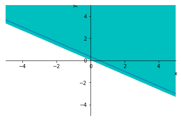

```python
p1=plot_implicit(2*x+3*y>0, line_color = 'c',show=False)
p2=plot(1/3-2/3*x, show=False)
p1.append(p2[0])
p1.show()
```

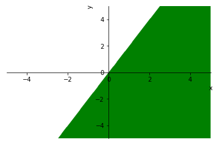

```
<sympy.plotting.plot.Plot at 0x7fc7c7ad97f0>
```

```python
plot_implicit(2*x-y>0, line_color = 'g')
```

## ¿Cómo se evalúan funciones de dos variables?

Dado que el dominio de dichas funciones son parejas ordenadas $(x,y)$ se requiere dar el valor de ambas variables para poder determinar el valor de la función.

### Ejemplo

Si $$g(x,y)=\sqrt{x^2+y^2-1}$$ halle el valor de $g(-3,4)$.

#### Solución:

$$g(-3,4)=\sqrt{(-3)^2+(4)^2-1}=\sqrt{9+16-1}=\sqrt{24}.$$

### Ejercicios

1. Dada la función $f(x,y)=3x^2-5xy+y^3$ halle el valor de: $f(1,2)$, $f(-1,-5)$ y $f(3,-2)$.
2. Si $g(x,y)=e^{2x^2y-5x+2y}$ evaluar $g$ en los siguientes puntos: $(0,0)$ y $(-1,1)$.
3. Considere $h(x,y)=ln(x^2+4x+y^2-1)$ calcule: $h(1,2)$, $h(0,-0.5)$ y $h(1/2,1/2)$.

## ¿Cómo se representan graficamente estas funciones?

Ya que el dominio es un subconjunto del plano cartesiano, para poder representar una función $f(x,y)$ se necesitará de un tercer eje coordenado, es decir, se deben representar tripletas del tipo $(x,y,f(x,y))$, donde las dos primeras entradas representan los elementos del dominio y la tercera entrada es la imagen de la pareja por medio de la función.

### Ejemplo

Si deseamos visualizar los puntos $(-3,4)$, $(-1,3)$ y sus imágenes mediante la función $g(x,y)=\sqrt{x^2+y^2-1}$

#### Solución:

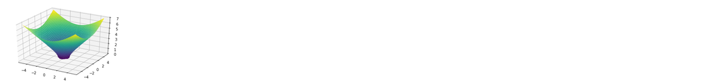

```
<sympy.plotting.plot.Plot at 0x7f7f9c1c9cc0>
```

```python
plot3d((x**2+y**2-1)**(1/2), (x, -5, 5), (y, -5, 5))
```

En Geogebra la visualización es mucho más amigable

[interactive chart not shown]

Para que desarrolle los siguientes ejercicios puede hacer uso de la herramienta que se encuentra en el siguiente link:

https://www.geogebra.org/3d?lang=es

### Ejercicios

1. Grafique las funciones:

   a. $f(x,y)=xy$. Ubique los puntos $(1,2,f(1,2))$ y $(3,4,f(3,4))$

   b. $g(x,y)=x^2+y^2$. Ubique los puntos $(0,0,g(0,0))$ y $(3,4,g(3,4))$

   c. $h(x,y)=x+y$. Ubique los puntos $(1,2,h(1,2))$ y $(3,-4,h(3,-4))$

## Aplicaciones

En la administración son muy importantes las funciones de más de una variable ya que, por ejemplo, los costos de una empresa que produce los artículos A y B viene dada por

$$C(x,y)=5x^2+20x+20y+y^2+1000$$

siendo $x$ la cantidad en miles de artículos elaborados del producto A, mientras que $y$ representa la cantidad en miles de artículos producidos de B.

Determine los costos de producir 1500 unidades de A y 2000 unidades de B.

```python
C.subs([(x,1.5),(y,2)])
```

$$1085.25$$

# Funciones de más de dos variables

Para las funciones de tres variables es mucho más complicado el estudio de los dominios ya que serán figuras de tres dimensiones, y para las que tengan más variables será imposible representar su dominio, por tal motivo no nos centraremos en los dominios, estudiaremos únicamente la forma de evaluarlas y algo de sus aplicaciones.

## ¿Cómo se evalúan?

```python
f=3*x+y**3-5*x*z
```

```python
f.subs([(x,1),(y,-2),(z,0)])
```

$$-5$$

### Ejemplo

Supongamos que los costos, en miles de dólares, de cierta fábrica vienen dados por $$C(x,y,z,w)=2x+7y+5z+6w+150$$ donde $x,y,z$ y $w$ son las cantidades en miles de unidades de los productos $X,\ Y,\ Z$ y $W$ respectivamente. Determine los costos totales de producir 1500 unidades del producto $X$, 2000 del $Y$, 100 del $Z$ y 3750 del $W$.

Solución

```python
C=2*x+7*y+5*z+6*w+150
```

```python
C.subs([(x,1.5),(y,2),(z,0.1),(w,3.75)])
```

$$190.0$$

Los costos totales de la fábrica ascienden a los 190.000USD.